# Erwin Kreyzig - Problem Set 9.5 Parametric Curves

## 1-10 What curves are represented by the following? Sketch them.

## 1.

**Parametric Representation**: $[3 + 2 \cos t, 2 \sin t, 0]$

$x = 3 + 2 \cos t$, $y = 2 \sin t$, $z=0.$

Let $u = \cos t$, $v = \sin t$, so $u^2 + v^2 = 1.$

Then $u = \frac{x - 3}{2}$, $v = \frac{y}{2}.$

Thus, $$ \left(\frac{x - 3}{2}\right)^2 + \left(\frac{y}{2}\right)^2 = u^2 + v^2 = 1 .$$

**Curve**: Circle with center $(3,0)$ in the $xy$-plane ($z = 0$).

**Equation**: $$ \left(\frac{x - 3}{2}\right)^2 + \left(\frac{y}{2}\right)^2 = 1 $$.

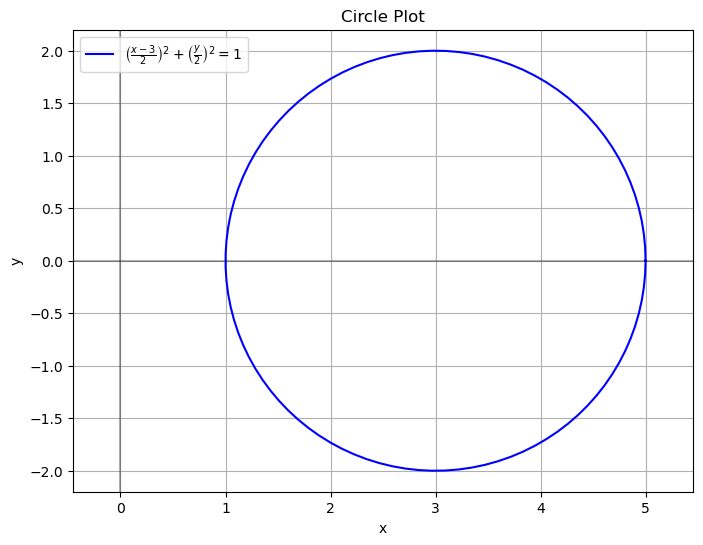

```python
import numpy as np
import matplotlib.pyplot as plt

# Create parameter t for parametric equations
t = np.linspace(0, 2*np.pi, 100)

# Parametric equations for the ellipse
# x = h + a*cos(t), y = k + b*sin(t)
# where (h,k) is center, a is horizontal radius, b is vertical radius
# circle special case when a = b = r, radius r
x = 3 + 2 * np.cos(t)  # h=3, a=2
y = 0 + 2 * np.sin(t)  # k=0, b=2

# Create the plot
plt.figure(figsize=(8, 6))
plt.plot(x, y, 'b-', label=r'$\left(\frac{x-3}{2}\right)^2 + \left(\frac{y}{2}\right)^2 = 1$')

# Add grid and axes
plt.grid(True)
plt.axhline(y=0, color='k', linestyle='-', alpha=0.3)
plt.axvline(x=0, color='k', linestyle='-', alpha=0.3)

# Set equal aspect ratio to show true ellipse shape
plt.axis('equal')

# Add labels and title
plt.xlabel('x')
plt.ylabel('y')
plt.title('Circle Plot')
plt.legend()

# Show the plot
plt.show()
```

### 2.

**Parametric Equation**: $[a + t, b + 3t, c - 5t]$

$x = a + t$, $y = b + 3t$, $z = c - 5t.$

Let $t = 0.$ Then, $x = a, y = b, z = c.$ Thus the curve passes through $(a, b, c)$.

If $t \neq 0$, the displacement $(t, 3t, -5t)$ is added to the point $(a, b, c).$. Thus, it is a line in the direction $(1, 3, -5)$ through $(a, b, c).$

To get non-parametric equation relating x, y, z without involving t, solving for $t$, we get $t =x - a$. Substituting back in, $y = b + 3(x - a)$, $z = c - 5(x - a).$

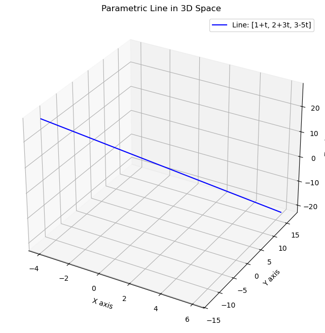

```python
# Import required libraries
import numpy as np
import matplotlib.pyplot as plt
from mpl_toolkits.mplot3d import Axes3D

# Define constants
a = 1  # You can change these values
b = 2
c = 3

# Create parameter t
t = np.linspace(-5, 5, 100)  # Creates 100 points from -5 to 5

# Calculate x, y, z coordinates
x = a + t
y = b + 3*t
z = c - 5*t

# Create the 3D plot
fig = plt.figure(figsize=(10, 8))
ax = fig.add_subplot(111, projection='3d')

# Plot the line
ax.plot(x, y, z, 'b-', label=f'Line: [{a}+t, {b}+3t, {c}-5t]')

# Set labels
ax.set_xlabel('X axis')
ax.set_ylabel('Y axis')
ax.set_zlabel('Z axis')
ax.set_title('Parametric Line in 3D Space')

# Add legend
ax.legend()

# Add grid
ax.grid(True)

# Show plot
plt.show()
```

### 3.

**Parametric Representation:** $[0, t, t^3]$

We want to eliminate $t.$

Using $y = t,$ we get $z = t^3.$

Substitute $t = y$ back in, so $z = y^3.$

**Curve**: Cubic curve in the $yz$-plane ($x = 0$) given by quation $z = y^3.$

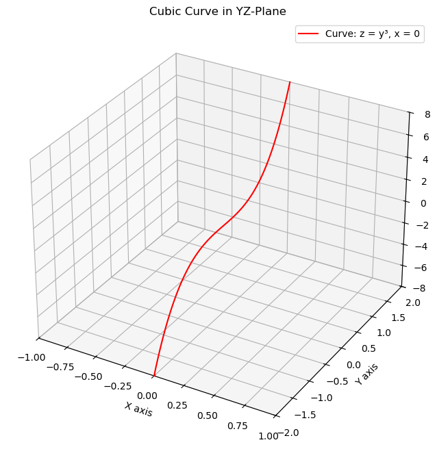

```python
# Import required libraries
import numpy as np
import matplotlib.pyplot as plt
from mpl_toolkits.mplot3d import Axes3D

# Create y values
y = np.linspace(-2, 2, 100)  # Creates 100 points from -2 to 2

# Calculate x and z coordinates
x = np.zeros_like(y)  # x = 0 for all points
z = y**3  # z = y³

# Create the 3D plot
fig = plt.figure(figsize=(10, 8))
ax = fig.add_subplot(111, projection='3d')

# Plot the curve
ax.plot(x, y, z, 'r-', label='Curve: z = y³, x = 0')

# Set labels
ax.set_xlabel('X axis')
ax.set_ylabel('Y axis')
ax.set_zlabel('Z axis')
ax.set_title('Cubic Curve in YZ-Plane')

# Set axis limits to better visualize the curve
ax.set_xlim(-1, 1)  # Small range since x is always 0
ax.set_ylim(-2, 2)
ax.set_zlim(-8, 8)  # Larger range since z = y³

# Add legend
ax.legend()

# Add grid
ax.grid(True)

# Show plot
plt.show()
```

### 4.

**Parametric Representation:** $[-2, 2 + 5 \cos t, -1 + 5 \sin t]$

We have $x=-2, y = 2 + 5 \cos t$ and $z = -1 + 5 \sin t.$

Let $u = \cos t$, $v = \sin t$, so $u^2 + v^2 = 1.$

But solving for $u = \cos t$ and $v = \sin t$ in terms of $y$ and $z$ gives $ u = \frac{y - 2}{5}$ and $v = \frac{z + 1}{5}.$

Thus, we have equations without $t$:

$$ \left(\frac{y - 2}{5}\right)^2 + \left(\frac{z + 1}{5}\right)^2 = 1 .$$

Or:

$$ (y - 2)^2 + (z + 1)^2 = 5^2 ,$$

while $x = -2.$

This is a circle in the $yz$-plane centered at $(-2, 2, -1)$, radius 5, translated to $x = -2$.

### 5.

**Paremetric Representation:**$[2 + 4 \cos t, 1 + \sin t, 0]$

$x = 2 + 4 \cos t$, $y = 1 + \sin t, z=0$.

Let $u = \cos t$, $v = \sin t$, so $u^2 + v^2 = 1$.

Then $\frac{x - 2}{4} = u$, $\frac{y - 1}{1} = v$.

Thus, $$ \left(\frac{x - 2}{4}\right)^2 + \left(\frac{y - 1}{1}\right)^2 = 1 $$.

**Curve**: Ellipse in the $xy$-plane ($z = 0$) centered at $(2, 1, 0)$, semi-major axis $4$ ($x$), semi-minor axis $1$ ($y$).

An ellipse has two axes. The bigger axis is called major axis and smaller one minor axis. Instead of radius for circle, we have two values, the lengths of semi-major axis and semi-minor axis.

An ellipse in general co-ordinates in two dimensions may be transformed to the above form equation by translation and rotation of the cartesian co-ordinates.

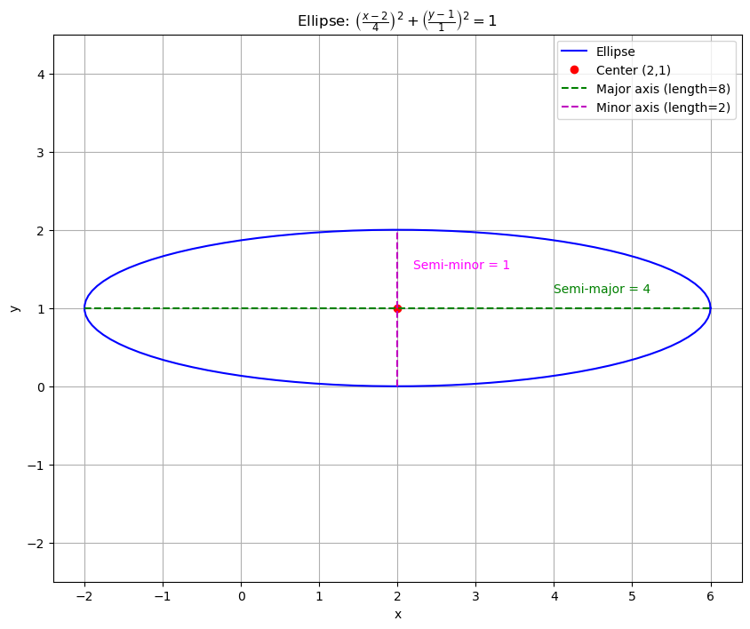

```python
import numpy as np
import matplotlib.pyplot as plt

# Create parameter t for parametric form
t = np.linspace(0, 2*np.pi, 100)

# Parametric equations for ellipse
x = 2 + 4 * np.cos(t)  # center x=2, semi-major axis=4
y = 1 + 1 * np.sin(t)  # center y=1, semi-minor axis=1

# Create the plot
plt.figure(figsize=(10, 8))
plt.plot(x, y, 'b-', label='Ellipse')

# Plot center point
plt.plot(2, 1, 'ro', label='Center (2,1)')

# Major axis (x-direction, length 8 = 2*4)
plt.plot([2-4, 2+4], [1, 1], 'g--', label='Major axis (length=8)')
# Minor axis (y-direction, length 2 = 2*1)
plt.plot([2, 2], [1-1, 1+1], 'm--', label='Minor axis (length=2)')

# Add annotations for axes lengths
plt.text(2+2, 1.2, 'Semi-major = 4', color='green')
plt.text(2.2, 1.5, 'Semi-minor = 1', color='magenta')

# Set equal aspect ratio
plt.axis('equal')

# Add grid and labels
plt.grid(True)
plt.xlabel('x')
plt.ylabel('y')
plt.title('Ellipse: $\\left(\\frac{x-2}{4}\\right)^2 + \\left(\\frac{y-1}{1}\\right)^2 = 1$')
plt.legend()

# Show the plot
plt.show()
```

### 6.

**Parametric Representation:** $[a + 3 \cos \pi t, b - 2 \sin \pi t, 0]$

- **Curve**: Ellipse in the $xy$-plane ($z = 0$).
- **Derivation**: $x = a + 3 \cos \pi t$, $y = b - 2 \sin \pi t$. Let $u = \cos \pi t$, $v = \sin \pi t$, so $u^2 + v^2 = 1$. Then $\frac{x - a}{3} = u$, $\frac{y - b}{-2} = v$. Thus, $$ \left(\frac{x - a}{3}\right)^2 + \left(\frac{y - b}{2}\right)^2 = 1 $$.
- **Equation**: $$ \left(\frac{x - a}{3}\right)^2 + \left(\frac{y - b}{2}\right)^2 = 1 $$.
- **Sketch**: Ellipse centered at $(a, b, 0)$, semi-major axis 3 ($x$), semi-minor axis 2 ($y$).

### 7.

**Parametric Representation:** $[4 \cos t, 4 \sin t, 3t]$

$x = 4 \cos t$, $y = 4 \sin t$, $z = 3t$.

Then $x^2 + y^2 = (4 \cos t)^2 + (4 \sin t)^2 = 16 (\cos^2 t + \sin^2 t) = 16 = 4^2$.

So, $x^2 + y^2 = 16$, with $z = 3t$.

**Curve**: Circular helix in 3D, with $x, y$ co ordinates along a circle with center at origin and radius $4.$ The helix rises along $z$ co-ordinate at the rate of three units per $t.$.

Even though the equation relating $x, y$ can be obtained as that of a circle, the the parametric form for the helix cannot be really removed as it's required for the $z$-coordinate.

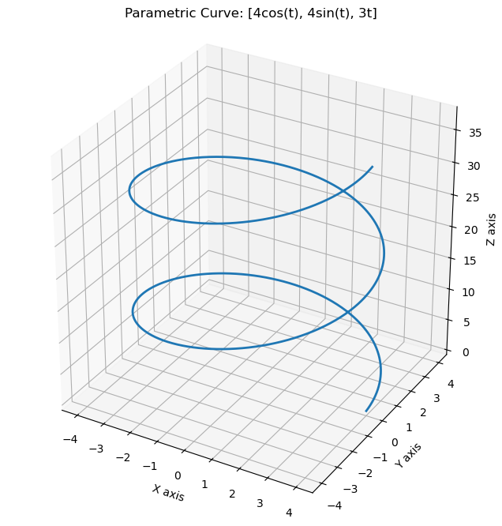

```python
import numpy as np
import matplotlib.pyplot as plt
from mpl_toolkits.mplot3d import Axes3D

# Create parameter t
t = np.linspace(0, 4*np.pi, 1000)  # Adjust range as needed

# Calculate x, y, z coordinates
x = 4 * np.cos(t)
y = 4 * np.sin(t)
z = 3 * t

# Create the 3D plot
fig = plt.figure(figsize=(10, 8))
ax = fig.add_subplot(111, projection='3d')

# Plot the parametric curve
ax.plot(x, y, z, lw=2)

# Add labels and title
ax.set_xlabel('X axis')
ax.set_ylabel('Y axis')
ax.set_zlabel('Z axis')
ax.set_title('Parametric Curve: [4cos(t), 4sin(t), 3t]')

# Optional: Set equal aspect ratio
ax.set_box_aspect([1,1,1])

# Show the plot
plt.show()
```

### 8.

**Parametric Representation:** $[\cosh t, \sinh t, 2]$

Instead of the circular trigonometric functions $\sin,$ $\cos$, the parametrization is by the hyperbolic trigonometric functions $\sinh$ and $\cosh.$

We have $x = \cosh t$, $y = \sinh t, z = 2.$

Using $\cosh^2 t - \sinh^2 t = 1$, we get $x^2 - y^2 = 1.$

**Curve**: Hyperbola in the $xy$-plane with offset $z = 2$ with equation: $x^2 - y^2 = 1$, opens along $x$-axis, centered at $(0, 0, 2)$.

When we have the hyperbolic trigonometric functions in the parametric representation, we get a hyperbola as the equation. When we had the circular trigonometric functions in parametric representation, we had got the circle.

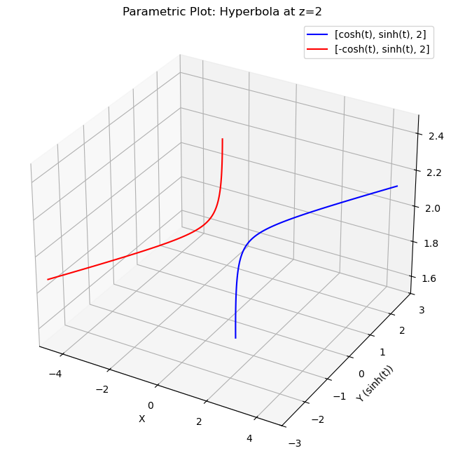

```python
import numpy as np
import matplotlib.pyplot as plt
from mpl_toolkits.mplot3d import Axes3D

# Create parameter t range
t = np.linspace(-2, 2, 100)

# Calculate coordinates for first branch (positive x)
x1 = np.cosh(t)
y1 = np.sinh(t)
z1 = np.full_like(t, 2)

# Calculate coordinates for second branch (negative x)
x2 = -np.cosh(t)
y2 = np.sinh(t)
z2 = np.full_like(t, 2)

# Create the 3D plot
fig = plt.figure(figsize=(10, 8))
ax = fig.add_subplot(111, projection='3d')

# Plot both branches
ax.plot(x1, y1, z1, 'b-', label='[cosh(t), sinh(t), 2]')
ax.plot(x2, y2, z2, 'r-', label='[-cosh(t), sinh(t), 2]')

# Set labels
ax.set_xlabel('X')
ax.set_ylabel('Y (sinh(t))')
ax.set_zlabel('Z')
ax.set_title('Parametric Plot: Hyperbola at z=2')

# Add a legend
ax.legend()

# Set reasonable axis limits to see both branches clearly
ax.set_xlim(-5, 5)
ax.set_ylim(-3, 3)
ax.set_zlim(1.5, 2.5)

# Show the plot
plt.show()
```

### 9.

**Parametric Representation:** $[\cos t, \sin 2t, 0]$

We have $x = \cos t$, $y = \sin 2t,$ $z =0.$

Since the $z$-component is zero, the curve lies in the $xy$-plane, with:

**Parametric Behavior:**

- $x = \cos t$: Period $2\pi$. Value between $\pm 1$.
- $y = \sin 2t$: Period $\pi$.

Such parametrization using $cos$ and $sin$ functions with different speed/frequency for $x$ and $y$ give rise to a type of figure-$8$ shape called Lissajous curve.

Use the trigonometric formula $\sin 2t = 2 \sin t \cos t.$,

But $\cos t = x,$ and $y = \sin t = \pm \sqrt{1 - \cos^2 t} = \pm \sqrt{1 - x^2}$

The frequency ratio (1:2) suggests a Lissajous curve, where (x) and (y) are sinusoidal functions with integer-related frequencies.

Such curves are explained here: https://mathworld.wolfram.com/LissajousCurve.html

In the following page, this curve is traced in the first example, with horizontal figure-$8$ or bow tie shape: https://jwilson.coe.uga.edu/emt668/emat6680.2003.fall/shiver/assignment10/assignment10.htm

#### Eliminating the Parameter

- $x = \cos t$, so $\cos t = x$, $\sin t = \pm \sqrt{1 - x^2}$.
- $y = \sin 2t = 2 \sin t \cos t = 2 (\pm \sqrt{1 - x^2}) x$.

Thus:

$$ y = \pm 2 x \sqrt{1 - x^2} $$

Square both sides:

$$ y^2 = 4 x^2 (1 - x^2) $$

#### Shape

$1-x^2$ is negative if $x> 1$ or $x<-1.$ Thus $y^2,$ which has to be a positive quanity, is defined only if $-1 \leq x \leq 1.$

If $y$ is a solution, then so is $-y$. The figure is symmetric about $x-$ axis. Likewise it is symmetric about $y-$ axis.

The value of the right side expression approaches zero at the origin. It also approaches $0$ at $x = \pm 1.$.

Plotting the curve, we see it's a horizontal figure eight curve (bowtie).$.

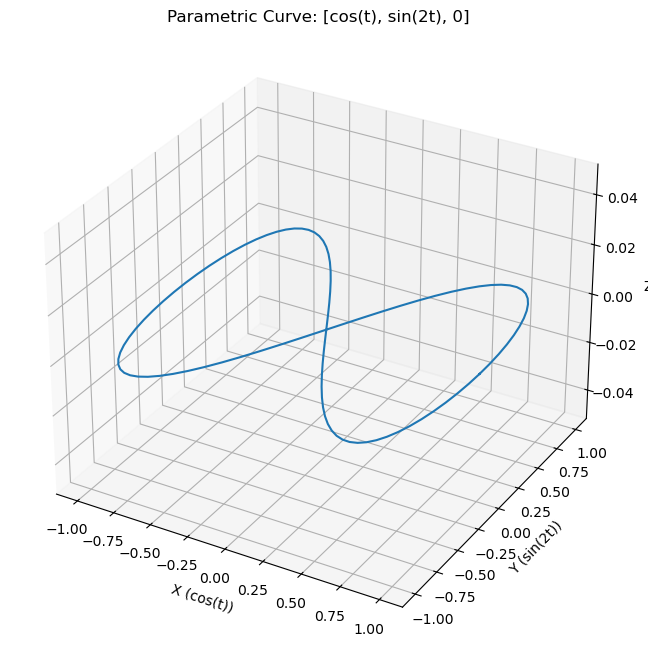

```python
import numpy as np
import matplotlib.pyplot as plt
from mpl_toolkits.mplot3d import Axes3D

# Create parameter t
t = np.linspace(0, 2*np.pi, 100)

# Calculate x, y, z coordinates
x = np.cos(t)
y = np.sin(2*t)
z = np.zeros_like(t)  # z = 0 for all points

# Create the 3D plot
fig = plt.figure(figsize=(10, 8))
ax = fig.add_subplot(111, projection='3d')

# Plot the curve
ax.plot(x, y, z)

# Set labels
ax.set_xlabel('X (cos(t))')
ax.set_ylabel('Y (sin(2t))')
ax.set_zlabel('Z')
ax.set_title('Parametric Curve: [cos(t), sin(2t), 0]')

# Add grid
ax.grid(True)

# Show the plot
plt.show()
```

### 10.

**Parametric Representation:** $[t, 2, 1/t]$

$y$ is costant, with value $2$. Therefore the curve is in the plane $y=2$, parallel to the $xz$ plane.

$x = t$, $z = 1/t$. Substitute $t = x$, so $z = 1/x$ (for $x \neq 0$).

Thus it's a hyperbola in the $z = 1/x$ in $xz$-plane, with $y = 2$ where $x$ and $z$ are inversely related, and the two axes $x$ and $z$ are asymptotes.

## 11–20 FIND A PARAMETRIC REPRESENTATION

#### 11

**Circle in the plane $z = 1$ with center $(3, 2)$ and passing through the origin.**

A circle is parameterized using trigonometric functions $\cos$ and $\sin.$

Since the circle lies in the plane $z = 1$, the $z$-coordinate is constant.

The center is $(3, 2, 1)$, and the circle passes through the point $(0, 0, 1)$ in the plane $z=1$ corresponding to origin $0,0$ in $xy$ plane.

The equation for the circle in $xy$ plane with center $(a, b)$ with radius $r$ is $(x-x_c)^2 + (y-y_c)^2 = r^2).$

Here $(x_c, y_c) = (3, 2)$ and $r$ is the distance between $(3, 2)$ and $(0,0)$, which is $\sqrt{3^2 + 2^2} = \sqrt{13}.$

The parametric representation for the same is set up as $(x-x_c) = r\cos t$ and $(y-y_c) = r\sin t,$ where $t = \theta$ represents the angle made by the point $(x, y)$ on the circle. Thus the equation is:

$$ x = 3 + \sqrt{13} \cos t, \quad y = 2 + \sqrt{13} \sin t, \quad z = 1, $$ where $t \in [0, 2\pi)$.

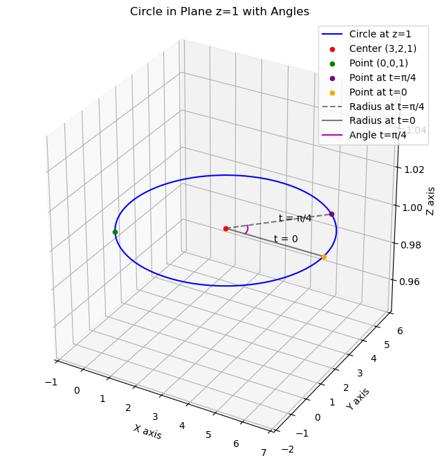

```python
import numpy as np
import matplotlib.pyplot as plt
from mpl_toolkits.mplot3d import Axes3D

# Create parameter t for the circle
t = np.linspace(0, 2*np.pi, 100)  # 100 points from 0 to 2π

# Calculate radius
r = np.sqrt(13)

# Parametric equations for the circle
x = 3 + r * np.cos(t)
y = 2 + r * np.sin(t)
z = np.ones_like(t)  # z = 1 for all points

# Specific point at t = π/4
t_point = np.pi/4
x_point = 3 + r * np.cos(t_point)
y_point = 2 + r * np.sin(t_point)
z_point = 1

# Point at t = 0
x_zero = 3 + r * np.cos(0)
y_zero = 2 + r * np.sin(0)
z_zero = 1

# Points for angle arc (smaller radius near center)
arc_radius = r * 0.2  # Small radius for angle visualization
t_arc = np.linspace(0, t_point, 20)  # Points from 0 to π/4
x_arc = 3 + arc_radius * np.cos(t_arc)
y_arc = 2 + arc_radius * np.sin(t_arc)
z_arc = np.ones_like(t_arc)

# Create 3D plot
fig = plt.figure(figsize=(10, 8))
ax = fig.add_subplot(111, projection='3d')

# Plot the circle
ax.plot(x, y, z, 'b-', label='Circle at z=1')

# Plot the center point
ax.scatter([3], [2], [1], color='red', label='Center (3,2,1)')

# Plot the origin point
ax.scatter([0], [0], [1], color='green', label='Point (0,0,1)')

# Plot the specific point at t = π/4
ax.scatter([x_point], [y_point], [z_point], color='purple', label='Point at t=π/4')

# Plot the point at t = 0
ax.scatter([x_zero], [y_zero], [z_zero], color='orange', label='Point at t=0')

# Add line from center to t = π/4 point
ax.plot([3, x_point], [2, y_point], [1, 1], 'k--', alpha=0.5, label='Radius at t=π/4')

# Add line from center to t = 0 point
ax.plot([3, x_zero], [2, y_zero], [1, 1], 'k-', alpha=0.5, label='Radius at t=0')

# Plot the angle arc
ax.plot(x_arc, y_arc, z_arc, 'm-', label='Angle t=π/4')

# Annotate the angles
ax.text(x_point/2 + 1.5, y_point/2 + 1, 1, 't = π/4', fontsize=10)
ax.text(x_zero/2 + 1.5, y_zero/2 + 1, 1, 't = 0', fontsize=10)

# Set labels and title
ax.set_xlabel('X axis')
ax.set_ylabel('Y axis')
ax.set_zlabel('Z axis')
ax.set_title('Circle in Plane z=1 with Angles')

# Set equal aspect ratio
ax.set_box_aspect([1,1,1])

# Add legend
ax.legend()

# Add grid
ax.grid(True)

# Show plot
plt.show()
```

#### 12

**Circle in the yz-plane with center $(4, 0)$ and passing through $(0, 3)$. Sketch it.**

In the $yz$-plane, $x = 0$. The circle is parameterized using $y$ and $z$ coordinates with trigonometric functions, centered at $(0, 4, 0)$ (adjusted for the yz-plane context).

The parametric equations are $y = y_c + r \cos t$, $z = z_c + r \sin t$, with $x = 0$.

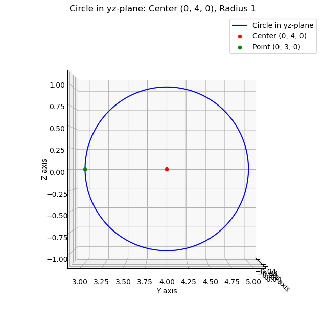

```python
import numpy as np
import matplotlib.pyplot as plt
from mpl_toolkits.mplot3d import Axes3D

# Create parameter t
t = np.linspace(0, 2*np.pi, 100)

# Parametric equations
x = np.zeros_like(t)  # x = 0 (yz-plane)
y = 4 + np.cos(t)     # y = 4 + cos(t)
z = np.sin(t)         # z = sin(t)

# Create 3D plot
fig = plt.figure(figsize=(8, 8))
ax = fig.add_subplot(111, projection='3d')

# Plot the circle
ax.plot(x, y, z, 'b-', label='Circle in yz-plane')

# Plot the center point
ax.scatter([0], [4], [0], color='red', label='Center (0, 4, 0)')

# Plot the point it passes through
ax.scatter([0], [3], [0], color='green', label='Point (0, 3, 0)')

# Set labels
ax.set_xlabel('X axis')
ax.set_ylabel('Y axis')
ax.set_zlabel('Z axis')
ax.set_title('Circle in yz-plane: Center (0, 4, 0), Radius 1')

# Set equal aspect ratio
ax.set_box_aspect([1,1,1])

# Add legend
ax.legend()

# Adjust view to emphasize yz-plane
ax.view_init(elev=0, azim=0)

plt.show()
```

#### 13

**Straight line through $(2, 1, 3)$ in the direction of $\mathbf{i} + 2\mathbf{j}$.**

A line in 3D space is parameterized using a point on the line and a direction vector. The direction vector $\mathbf{i} + 2\mathbf{j}$ corresponds to $(1, 2, 0)$.

The line passes through $(2, 1, 3)$ with direction vector $\mathbf{d} = (1, 2, 0)$.

The parametric form is $\mathbf{r}(t) = \mathbf{r_0} + t\mathbf{d}$, where $\mathbf{r_0} = (2, 1, 3)$.

**Parametric Representation:**
$$ x = 2 + t, \quad y = 1 + 2t, \quad z = 3, $$ where $t \in \mathbb{R}$.

**Note:** The $z$-coordinate remains constant since the direction vector has no $z$-component.

#### 14

**Straight line through $(1, 1, 1)$ and $(4, 0, 2)$. Sketch it.**

The parametric equation of a line through two points uses the direction vector as the difference of the points.

Direction vector $\mathbf{d} = (4-1, 0-1, 2-1) = (3, -1, 1)$.

The line passes through $(1, 1, 1)$, so $\mathbf{r}(t) = (1, 1, 1) + t(3, -1, 1)$.

Thus, Parametric Representation: $$ x = 1 + 3t, \quad y = 1 - t, \quad z = 1 + t, $$ where $t \in \mathbb{R}$.

The line starts at $(1, 1, 1)$ and moves toward $(4, 0, 2)$. As $t$ increases, $x$ and $z$ increases and $y$ decreases.

#### 15

**Straight line $y = 4x - 1, z = 5x.$**

We have to represent $x, y, z$ in terms of a parameter $t.$. Here already $y$ and $z$ can be represented in terms of $x.$. Therefore we can use $x$ as the parameter and set $t=x.$. Then $y = 4t - 1$ and $z = 5t.$ Thus Parametric representation is:

$$ x = t, \quad y = 4t - 1, \quad z = 5t, $$ where $t \in \mathbb{R}$.

#### 16

**The intersection of the circular cylinder of radius 1 about the z-axis and the plane $z = y$.**

A cylinder of radius 1 about the z-axis has the equation $x^2 + y^2 = 1$.

If $x, y$ are represented in parametric form by a parameter $t$, then the intersection of above with $z = y$ has $z = y$ in the parametrization.

For parametric representation, use $x = \cos t$, $y = \sin t$, and $z = y = \sin t.$

The intersection is an ellipse in the plane $z = y.$ It projects to a circle to both the $xy$-plane and $xz$-plane. Its semi minor axis has length $1$ while semi major axis has length $\sqrt 2.$

#### 17

**Circle $\frac{1}{2} x^2 + y^2 = 1, z = y$.**

The first equation is: $$x^2/2 + y^2 = 1$$ This is an ellipse in the xy-plane with:

- Semi-major axis $a = \sqrt{2}$ along x-axis (since $x^2/2 = x^2/(\sqrt{2})^2$)
- Semi-minor axis $b = 1$ along y-axis

To parametrize this in $xy$ plane, we can use:

- $x = \sqrt{2} \cos(t)$
- $y = \sin(t)$ where $t \in [0, 2\pi)$

Since $z = y,$ we can write parametrization for the third co-ordinate also:

- $z = \sin(t).$

#### 18

**Helix $x^2 + y^2 = 25, z = 2 \arctan(y/x).$**

A helix is parameterized using circular motion in the $xy$-plane with a linear or other $z$-component.

Here, $x^2 + y^2 = 25$ is a circle of radius 5.

This can be parametrized as $x = 5 \cos t,$ $y = 5 \sin t.$

Thus $z = 2 \arctan(y/x) = 2 \arctan \left(\frac{\sin t}{\cos t}\right) = 2t.$

Thus, Parametric Representation is:

$$ x = 5 \cos t, \quad y = 5 \sin t, \quad z = 2t , $$ where $t = \theta \in \mathbb{R}$ represents the angle (e.g., $[0, 2\pi)$ for one turn).

#### 19

**Hyperbola $4x^2 - 3y^2 = 4, z = -2$**

A hyperbola in the $xy$-plane is parameterized using hyperbolic functions $\cosh t$ and $\sinh t.$ In the given case, it is a hyperbola in the plane $z= -2.$

Just as we have the relation $\cos^2 t + \sin^2 t = 1$ for the circular trigonometric functions, we have $\cosh^2 t - \sinh^2 t = 1$ for the hyperbolic trigonometric functions. We use the latter to represent a hyperbola in parametric form.

The standard form of an ellipse centered at the origin is:

$$ \frac{x^2}{a^2} + \frac{y^2}{b^2} = 1 $$

where $a > b > 0$, $a$ is the semi-major axis, and $b$ is the semi-minor axis.

Similarly the standard form of a hyperbola centered at the origin (opening left and right) is:

$$ \frac{x^2}{a^2} - \frac{y^2}{b^2} = 1 $$

where $a$ and $b$ are positive constants, and the asymptotes are $y = \pm \frac{b}{a}x.$

Rewrite given curve equation as $4x^2 - 3y^2 = 4$ as $\frac{x^2}{1} - \frac{y^2}{4/3} = 1.$

Use $x = \cosh t$, $y = \frac{2}{\sqrt{3}} \sinh t$, so:

$$ 4(\cosh t)^2 - 3\left(\frac{2}{\sqrt{3}} \sinh t\right)^2 = 4(\cosh^2 t - \sinh^2 t) = 4.$$

Also set set $z = -2.$ Thus the parametric representation is:

$$ x = \cosh t, \quad y = \frac{2}{\sqrt{3}} \sinh t, \quad z = -2, $$ where $t \in \mathbb{R}$.

#### 20

**Intersection of $2x - y + 3z = 2$ and $x + 2y - z = 3$**

The intersection of two planes in 3D space is a straight line (unless the planes are parallel). To find a parametric representation, solve the system of equations to express two variables in terms of a third, then parameterize the line.

We can do in the manner of Gauss elimination for matrices or work directly with equations.

**Derivation:**

- The given planes are:
  $$ 2x - y + 3z = 2 \quad (1) $$
  $$ x + 2y - z = 3 \quad (2) $$
- Solve the system by eliminating one variable. Multiply equation (2) by 3 to align the $z$ terms:
  $$ 3(x + 2y - z) = 3(3) \implies 3x + 6y - 3z = 9 \quad (3) $$
- Add equation (1) and equation (3) to eliminate $z$:
  $$ (2x - y + 3z) + (3x + 6y - 3z) = 2 + 9 \implies 5x + 5y = 11 \implies x + y = \frac{11}{5} \implies y = \frac{11}{5} - x. $$
- Substitute $y = \frac{11}{5} - x$ into equation (2) to solve for $z$:
  $$ x + 2\left(\frac{11}{5} - x\right) - z = 3 \implies x + \frac{22}{5} - 2x - z = 3 \implies -x + \frac{22}{5} - z = 3 \implies z = -x + \frac{22}{5} - 3 = -x + \frac{22}{5} - \frac{15}{5} = -x + \frac{7}{5}. $$
- Now, let $x = t$ (as the parameter). Then:
  $$ y = \frac{11}{5} - t, \quad z = -t + \frac{7}{5}. $$

**Parametric Representation:**
$$ x = t, \quad y = \frac{11}{5} - t, \quad z = \frac{7}{5} - t, $$ where $t \in \mathbb{R}$.

**Verification:**

- Substitute into equation (1): $2(t) - \left(\frac{11}{5} - t\right) + 3\left(\frac{7}{5} - t\right) = 2t - \frac{11}{5} + t + \frac{21}{5} - 3t = \frac{10}{5} = 2$, which holds.
- Substitute into equation (2): $t + 2\left(\frac{11}{5} - t\right) - \left(\frac{7}{5} - t\right) = t + \frac{22}{5} - 2t - \frac{7}{5} + t = \frac{15}{5} = 3$, which holds.

**Note:** The line passes through the point $\left(0, \frac{11}{5}, \frac{7}{5}\right)$ when $t = 0$, and its direction vector is $(1, -1, -1)$.

## 24-28 Tangent

**Given a curve $C: \mathbf{r}(t)$, find a tangent vector $\mathbf{r}'(t)$, a unit tangent vector $\mathbf{u}'(t)$, and the tangent of $C$ at $P$. Sketch curve and tangent.**

#### 24

$ \mathbf{r}(t) = [ t, \frac{1}{2} t^2, 1] $, $ P: (2, 2, 1) $

To calculate tangent vector first compute derivative: $ \mathbf{r}'(t) = [ 1, t, 0 ] $

The point $P$ corresponds to $ t = 2 .$ There the tangent vector is $ \mathbf{r}'(2) = [ 1, 2, 0 ] .$

To calculate unit tangent vector, compute magnitude and divide the tangent vector by it:

Magnitude: $ |\mathbf{r}'(2)| = \sqrt{1^2 + 2^2 + 0^2} = \sqrt{5} $

Denoting by $\mathbf u^\prime$ the unit tangent vector, $ \mathbf{u}'(t) = \left[ \frac{1}{\sqrt{5}}, \frac{2}{\sqrt{5}}, 0 \right] $.

The tangent line at is the line through the point $P$ in the direction of the tangent vector.

Given by parametric equations $ x = 2 + s $, $ y = 2 + 2s $, $ z = 1 $ for parameter $s.$

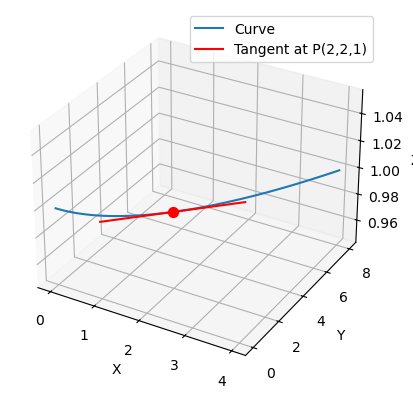

```python
import numpy as np
import matplotlib.pyplot as plt
from mpl_toolkits.mplot3d import Axes3D

# Curve
t = np.linspace(0, 4, 100)
x = t
y = 0.5 * t**2
z = np.ones_like(t)

# Tangent at t=2
t0 = 2
s = np.linspace(-1, 1, 20)
x_tan = 2 + s
y_tan = 2 + 2 * s
z_tan = np.ones_like(s)

# Plot
fig = plt.figure()
ax = fig.add_subplot(111, projection='3d')
ax.plot(x, y, z, label='Curve')
ax.plot(x_tan, y_tan, z_tan, 'r', label='Tangent at P(2,2,1)')
ax.scatter([2], [2], [1], color='red', s=50)
ax.set_xlabel('X')
ax.set_ylabel('Y')
ax.set_zlabel('Z')
ax.legend()
plt.show()
```

#### 25

**$ \mathbf{r}(t) = [10 \cos t, 1, 10 \sin t] $, $ P: (6, 1, 8) $**

For tangent vector:

$ \mathbf{r}'(t) = [-10 \sin t, 0, 10 \cos t] $

For $t$ corresponding to $P$ above, we know that $\sin t = 0.8, \cos t=0.6.$ Thus, $ \mathbf{r}'(t) = [-8, 0, 6] $.

Magnitude: $| \mathbf{r}'(t) | = \sqrt{(-8)^2 + 0^2 + 6^2} = \sqrt{64 + 36} = \sqrt{100} = 10$

Unit tangent vector: $\mathbf{T}(t) = \frac{\mathbf{r}'(t)}{| \mathbf{r}'(t) |} = \left( -0.8, 0, 0.6 \right)$

Tangent line at $ P $:
$$ x = 6 - 8s ,\quad y = 1 , \quad z = 8 + 6s .$$

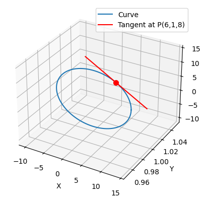

```python
import numpy as np
import matplotlib.pyplot as plt
from mpl_toolkits.mplot3d import Axes3D

# Curve
t = np.linspace(0, 2*np.pi, 100)
x = 10 * np.cos(t)
y = np.ones_like(t)
z = 10 * np.sin(t)

# Tangent at t=0.927
t0 = 0.927
s = np.linspace(-1, 1, 20)
x_tan = 6 - 8 * s
y_tan = np.ones_like(s)
z_tan = 8 + 6 * s

# Plot
fig = plt.figure()
ax = fig.add_subplot(111, projection='3d')
ax.plot(x, y, z, label='Curve')
ax.plot(x_tan, y_tan, z_tan, 'r', label='Tangent at P(6,1,8)')
ax.scatter([6], [1], [8], color='red', s=50)
ax.set_xlabel('X')
ax.set_ylabel('Y')
ax.set_zlabel('Z')
ax.legend()
plt.show()
```

#### 26

**$ \mathbf{r}(t) = [\cos t, \sin t, 9t] $, $ P: (1, 0, 18\pi) $**

Tangent vector:

$ \mathbf{r}'(t) = [-\sin t, \cos t, 9] $

At $ t = 2\pi $, $ \mathbf{r}'(2\pi) = [0, 1, 9] $.

Magnitude: $ |\mathbf{r}'(2\pi)| = \sqrt{82} $

Unit tangent vector: $ \mathbf{u}'(t) = \left[ 0, \frac{1}{\sqrt{82}}, \frac{9}{\sqrt{82}} \right] $.

Tangent line at $P$:

$$ x = 1 ,\quad y = s ,\quad z = 18\pi + 9s.$$

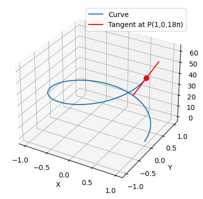

```python
import numpy as np
import matplotlib.pyplot as plt
from mpl_toolkits.mplot3d import Axes3D

# Curve
t = np.linspace(0, 2*np.pi, 100)
x = np.cos(t)
y = np.sin(t)
z = 9 * t

# Tangent at t=2pi
t0 = 2 * np.pi
s = np.linspace(-0.5, 0.5, 20)
x_tan = np.ones_like(s)
y_tan = s
z_tan = 18 * np.pi + 9 * s

# Plot
fig = plt.figure()
ax = fig.add_subplot(111, projection='3d')
ax.plot(x, y, z, label='Curve')
ax.plot(x_tan, y_tan, z_tan, 'r', label='Tangent at P(1,0,18π)')
ax.scatter([1], [0], [18*np.pi], color='red', s=50)
ax.set_xlabel('X')
ax.set_ylabel('Y')
ax.set_zlabel('Z')
ax.legend()
plt.show()
```

#### 27

**$ \mathbf{r}(t) = [ t, \frac{1}{t}, 0 ] $, $ P: ( 2, \frac{1}{2}, 0 ) $**

Tangent vector:

$ \mathbf{r}'(t) = [ 1, -\frac{1}{t^2}, 0 ] $

At $ t = 2 $, $ \mathbf{r}'(2) = [ 1, -\frac{1}{4}, 0 ] $.

Magnitude: $ |\mathbf{r}'(2)| = \frac{\sqrt{17}}{4} $

Unit tangent vector: $ \mathbf{u}'(t) = [ \frac{4}{\sqrt{17}}, -\frac{1}{\sqrt{17}}, 0 ] $.

Tangent line at $ P $:

$$ x = 2 + s, \quad y = \frac{1}{2} - \frac{1}{4}s, \quad z = 0 .$$

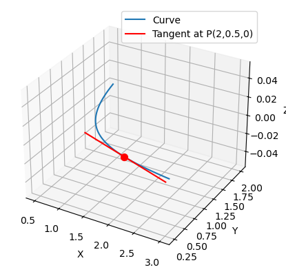

```python
import numpy as np
import matplotlib.pyplot as plt
from mpl_toolkits.mplot3d import Axes3D

# Curve
t = np.linspace(0.5, 3, 100)
x = t
y = 1 / t
z = np.zeros_like(t)

# Tangent at t=2
t0 = 2
s = np.linspace(-1, 1, 20)
x_tan = 2 + s
y_tan = 0.5 - 0.25 * s
z_tan = np.zeros_like(s)

# Plot
fig = plt.figure()
ax = fig.add_subplot(111, projection='3d')
ax.plot(x, y, z, label='Curve')
ax.plot(x_tan, y_tan, z_tan, 'r', label='Tangent at P(2,0.5,0)')
ax.scatter([2], [0.5], [0], color='red', s=50)
ax.set_xlabel('X')
ax.set_ylabel('Y')
ax.set_zlabel('Z')
ax.legend()
plt.show()
```

### 28

**$ \mathbf{r}(t) = [t, t^2, t^3] $, $ P: (1, 1, 1) $**

Tangent vector:

$ \mathbf{r}'(t) = [1, 2t, 3t^2] $

At $ t = 1 $, $ \mathbf{r}'(1) = [1, 2, 3] $.

Magnitude: $ |\mathbf{r}'(1)| = \sqrt{14} $

Unit tangent vector: $ \mathbf{u}'(t) = \left[ \frac{1}{\sqrt{14}}, \frac{2}{\sqrt{14}}, \frac{3}{\sqrt{14}} \right].$

Tangent line at $ P $:

$$ x = 1 + s, \quad y = 1 + 2s, \quad z = 1 + 3s .$$

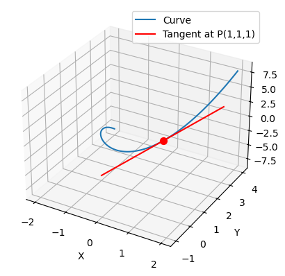

```python
import numpy as np
import matplotlib.pyplot as plt
from mpl_toolkits.mplot3d import Axes3D

# Curve
t = np.linspace(-2, 2, 100)
x = t
y = t**2
z = t**3

# Tangent at t=1
t0 = 1
s = np.linspace(-1, 1, 20)
x_tan = 1 + s
y_tan = 1 + 2 * s
z_tan = 1 + 3 * s

# Plot
fig = plt.figure()
ax = fig.add_subplot(111, projection='3d')
ax.plot(x, y, z, label='Curve')
ax.plot(x_tan, y_tan, z_tan, 'r', label='Tangent at P(1,1,1)')
ax.scatter([1], [1], [1], color='red', s=50)
ax.set_xlabel('X')
ax.set_ylabel('Y')
ax.set_zlabel('Z')
ax.legend()
plt.show()
```